# Ejemplo de aplicación con R: Comparación entre el videolaringoscopio Pentax AWS y el laringoscopio Macintosh

Humberto Martínez Bautista (https://orcid.org/0000-0001-6984-9430) Centro de Investigación en Matemáticas A.C. Unidad Aguascalientes.

2025-03-12. R: 4.4.1. Autor: humberto.martinez@cimat.mx

En este documento nos enfocaremos en presentar, revisar y aplicar algunas herramientas estadísticas vistas en el módulo 3 del Diplomado de Bioestadística aplicada, usando la publicación: *“A Randomized Comparison Between the Pentax AWS Video Laryngoscope and the Macintosh Laryngoscope in Morbidly Obese Patients”*, [ver aquí artículo](https://journals.lww.com/anesthesia-analgesia/Fulltext/2011/11000/A_Randomized_Comparison_Between_the_Pentax_AWS.24.aspx), publicado en *ANESTHESIA & ANALGESIA* (2011), revista oficial de la *International Anesthesia Research Society*.

Realizaremos una aplicación con R de estadística descriptiva, estadística inferencial, y de investigación, para validar la utilización del software libre R como herramienta para llevar a cabo el análisis estadístico en ciencias de la salud. Para ello, se presentarán los métodos, técnicas y ejemplos relevantes que permitan a los lectores comprender cómo utilizar dicha herramienta. Se asume cierta familiaridad con los conceptos estadísticos, se proporcionará una orientación paso a paso para la adecuada comprensión y aplicación.

Es importante precisar que este documento **NO ES UN TRABAJO EXHAUSTIVO** de aplicación estadística ni de ciencias de la salud y, sólo promueve la divulgación educativa para adentrase en las aplicaciones estadísticas. Para correcciones, contribuciones y trabajos especializados (o con mayor rigor estadístico) favor de ponerse en contacto con el autor de correspondencia.

A continuación, presentaremos el contexto y los generales relevantes de la aplicación que vamos a trabajar.

# 1 Fenómeno, problema o situación a trabajar y su contexto

La proporción de pacientes obesos y con obesidad mórbida está aumentando rápidamente en todo el mundo. Se conoce que en estos pacientes la intubación traqueal puede presentar mayor dificultad debido al espacio reducido y la limitación orofaríngea, misma que provoca una visualización inadecuada.(1) Las intubaciones traqueales difíciles y fallidas en estos pacientes se encuentran entre las principales causas de mortalidad y morbilidad relacionadas con la anestesia.(2)

Los especialistas en el área de la salud saben que una buena visión laríngea facilita la intubación traqueal y, por ello, se han introducido nuevas tecnologías para mejorar la visualización. Los videolaringoscopios, como Pentax AWS, suelen utilizar cámaras en miniatura para facilitar la visualización de la laringe.

El Pentax AWS (Figura 1.1) es un novedoso videolaringoscopio, disponible en Japón desde 2006, diseñado para facilitar la intubación proporcionando una imagen de vídeo de la glotis. Incorpora una cámara de vídeo en miniatura y un monitor LCD integrado alimentado por pilas con una cuchilla desechable que se acopla al sistema de base y, la incorporación de una pantalla LCD permite ver la glotis simultáneamente a la inserción del tubo endotraqueal. En este sentido, se diferencia de otros videolaringoscopios, los cuales utilizan monitores externos. El Pentax AWS también difiere en tener un canal lateral que posiciona la guía al tubo endotraqueal. Diversos estudios sugieren que este video-laringoscopio puede ayudar a intubar de mejor forma, pero los estudios aún siguen siendo escasos.(3) El método convencional para realizar laringoscopia ha sido con el laringoscopio Macintosh estándar con hoja nº4 (Figura 1.2). Siendo la principal diferencia no tener una cámara de video integrada como el Pentax AWS.(4)

[figure not shown]

Figure 1.1: Pentax AWS

[figure not shown]

Figure 1.2: Macintosh estándar

# 2 Objetivo de investigación

Comparar la eficacia entre el videolaringoscopio Pentax AWS y el laringoscopio Macintosh

# 3 Fuente de información o procedencia de los datos

La información se encuentra disponible en la paquetería `medicaldata` de R. Una vez instalada y activada esta librería se puede cargar la base de datos (BD) como se muestra a continuación.

```r
### Instalación

list.of.packages <- c("medicaldata", "Hmisc", "janitor","dplyr","ggplot2","cowplot","gmodels","rstatix","psych",
                      "RColorBrewer","ggpubr","car","stats", "corrplot", "tidyverse","MVN","DescTools",
                      "broom","survival", "survminer","vembedr", "kableExtra", "gtsummary", "forcats",
                      "MASS","smd")

new.packages <- list.of.packages[!(list.of.packages %in% installed.packages()[,"Package"])]
if(length(new.packages)) install.packages(new.packages)
```

```r
### Activación

# Manejo de datos

library(dplyr)
library(Hmisc)
library(janitor)
library(gmodels)
library(rstatix)
library(car)
library(stats)
library(tidyverse)
library(MVN)
library(DescTools)
library(broom)
library(survival)
library(survminer)
library(forcats)
library(MASS)
library(smd)

# Visualización de datos

library(ggplot2)
library(cowplot)
library(psych)
library(RColorBrewer)
library(ggpubr)
library(corrplot)
library(gtsummary)

# Incrustar videos de youtube
library(vembedr)

# Manejo de tablas
library(kableExtra)

# Creación de Rmarkdown
library(rmarkdown)

# Bases de datos (BD)
library(medicaldata)
```

```r
### Carga de datos
data(laryngoscope, package="medicaldata" )
names(laryngoscope) #Muestra los nombres de las variables en la BD original
```

```
#>  [1] "age"                      "gender"
#>  [3] "asa"                      "BMI"
#>  [5] "Mallampati"               "Randomization"
#>  [7] "attempt1_time"            "attempt1_S_F"
#>  [9] "attempt2_time"            "attempt2_assigned_method"
#> [11] "attempt2_S_F"             "attempt3_time"
#> [13] "attempt3_assigned_method" "attempt3_S_F"
#> [15] "attempts"                 "failures"
#> [17] "total_intubation_time"    "intubation_overall_S_F"
#> [19] "bleeding"                 "ease"
#> [21] "sore_throat"              "view"
```

# 4 Estrategia de análisis (criterios de inclusión o exclusión, tratamiento de datos, etc.)

# 5 Variables, factores o características asociadas a estudiar (operacionalización de variables)

Etiquetado de variables

Utilizaremos la función `rename()` para renombrar las variables, utilizar la siguiente estructura: “nuevo nombre” = “nombre antiguo”.

```r
laringoscopia <- rename(laryngoscope,
                 Edad = age, Sexo = gender, Estado_fisico = asa,
                 IMC = BMI, Mallampati = Mallampati, Grupo = Randomization,
                 Tiempo_total_intubacion = total_intubation_time,  Num_intentos = attempts, Nivel_dificultad = ease,
                 Tiempo_1_intento = attempt1_time, Exito_1_intento = attempt1_S_F,
                 Tiempo_2_intento = attempt2_time, Exito_2_intento = attempt2_S_F,
                 Metodo_2_intento = attempt2_assigned_method, Tiempo_3_intento = attempt3_time,
                 Metodo_3_intento = attempt3_assigned_method, Exito_3_intento = attempt3_S_F,
                 Fracasos = failures, Exito_intubacion = intubation_overall_S_F,
                 Sangrado = bleeding, Dolor_garganta = sore_throat, Vista_glotis = view)
```

Tipo de variables

Es importante definir los tipos de variables que se utilizarán en el análisis estadístico. En esta parte se utiliza la función `factor()` en la cual se indican las variables que serán declaradas como factores, sus niveles y las etiquetas de los niveles.

```r
# Factores del estudio

laringoscopia$Sexo <- factor(laringoscopia$Sexo, levels = c(0,1), labels = c("Femenino","Masculino"))

laringoscopia$Grupo <- factor(laringoscopia$Grupo, levels = c(0,1), labels = c("Macintosh","Pentax_AWS"))

laringoscopia$Estado_fisico <- factor(laringoscopia$Estado_fisico, levels = c(2,3,4), labels = c("II","III","IV"))

laringoscopia$Exito_1_intento <- factor(laringoscopia$Exito_1_intento, levels = c(0,1), labels = c("No","Si"))

laringoscopia$Exito_2_intento  <- factor(laringoscopia$Exito_2_intento , levels = c(0,1), labels = c("No","Si"))

laringoscopia$Exito_3_intento <- factor(laringoscopia$Exito_3_intento, levels = c(0,1), labels = c("No","Si"))

laringoscopia$Fracasos <- factor(laringoscopia$Fracasos, levels = c(1,2,3), labels = c("1","2","3"))

laringoscopia$Exito_intubacion <- factor(laringoscopia$Exito_intubacion, levels = c(0,1), labels= c("No","Si"))

laringoscopia$Sangrado  <- factor(laringoscopia$Sangrado , levels = c(0,1), labels = c("No","Si"))

laringoscopia$Dolor_garganta  <- factor(laringoscopia$Dolor_garganta , levels = c(0,1,2,3), labels = c("Ninguno","Leve","Moderado","Severo"))

laringoscopia$Vista_glotis  <- factor(laringoscopia$Vista_glotis , levels = c(0,1), labels = c("Malo","Bueno"))

laringoscopia$Metodo_2_intento <- factor(laringoscopia$Metodo_2_intento, levels = c(0,1), labels = c("No","Si"))

laringoscopia$Metodo_3_intento <- factor(laringoscopia$Metodo_3_intento, levels = c(0,1), labels = c("No","Si"))
```

** Primeros 10 pacientes **

```r
head(laringoscopia,10)
```

```
#>    Edad     Sexo Estado_fisico   IMC Mallampati     Grupo Tiempo_1_intento
#> 1    51 Femenino           III 56.20          1 Macintosh            29.00
#> 2    52 Femenino           III 44.60          2 Macintosh            29.00
#> 3    37 Femenino           III 41.60          1 Macintosh            31.00
#> 4    20 Femenino           III 46.32          2 Macintosh            31.00
#> 5    35 Femenino           III 61.00          2 Macintosh            21.00
#> 6    39 Femenino           III 44.00          2 Macintosh            10.00
#> 7    52 Femenino           III 44.00          2 Macintosh            13.00
#> 8    59 Femenino           III 41.90          2 Macintosh            23.00
#> 9    32 Femenino           III 47.00          1 Macintosh            15.00
#> 10   24 Femenino           III 45.00          1 Macintosh             8.96
#>    Exito_1_intento Tiempo_2_intento Metodo_2_intento Exito_2_intento
#> 1               Si               NA             <NA>            <NA>
#> 2               Si               NA             <NA>            <NA>
#> 3               No               60               Si              Si
```

[output cut: 40 more lines]

** Últimos 10 pacientes **

```r
tail(laringoscopia,10)
```

```
#>    Edad      Sexo Estado_fisico   IMC Mallampati      Grupo Tiempo_1_intento
#> 90   52  Femenino            II 44.20          1 Pentax_AWS               49
#> 91   72  Femenino           III 41.00          2 Pentax_AWS               30
#> 92   52  Femenino            II 34.10          2 Pentax_AWS               36
#> 93   58  Femenino           III    NA          1 Pentax_AWS               35
#> 94   49 Masculino           III 41.41          2 Pentax_AWS               47
#> 95   58 Masculino           III    NA          4 Pentax_AWS               49
#> 96   51  Femenino            II 41.10          1 Pentax_AWS               29
#> 97   59 Masculino           III 40.00          1 Pentax_AWS               29
#> 98   58  Femenino           III 34.09          1 Pentax_AWS               41
#> 99   52 Masculino            II 36.81          3 Pentax_AWS               34
#>    Exito_1_intento Tiempo_2_intento Metodo_2_intento Exito_2_intento
#> 90              No               49               Si              No
#> 91              Si               NA             <NA>            <NA>
#> 92              Si               NA             <NA>            <NA>
```

[output cut: 40 more lines]

**Operacionalización de variables**

[output not shown]

**NOTA IMPORTANTE.** Para la aplicación con R se utilizará la BD original y no la transformada.

# 6 Tipo de estudio. De acuerdo con módulo 1 del Diplomado

Ensayo clínico aleatorizado de dos brazos (grupos). La aleatorización fue con números aleatorios generados por computadora y la asignación de grupos fue ciega.

En todos los casos, la cabeza del paciente se colocó en posición neutral sobre una almohada de espuma “donut” y el laringoscopista era libre de manipular la cabeza según fuera necesario para obtener la mejor vista posible.

Todas las tráqueas de los pacientes fueron intubadas por 1 de 2 anestesiólogos asistentes, cada uno de los cuales había utilizado previamente el Pentax AWS de 5 a 10 veces antes de comenzar el estudio.

El estudio comienza con la administración de oxígeno y la inducción de la anestesia general en los pacientes para después asignarlos al azar a la técnica de intubación, ya sea Macintosh (n = 49) o el Pentax AWS (n = 50).

De 105 pacientes incluidos, cuatro no completaron el estudio por cancelación de cirugía o porque el anestesiólogo no pudo llegar al quirófano a tiempo, y dos pacientes del grupo Pentax AWS tuvieron resultados primarios faltantes. Por lo tanto, los datos están disponibles sólo para 99 pacientes.

En los siguientes videos, se muestra la intubación de pacientes.

[video not shown]

Para el que corresponde al laringoscopio Macintosh ver: https://www.youtube.com/watch?v=4b0M3zJcQ2A

# 7 Título del trabajo “adecuado”

**Comparación de eficacia entre el videolaringoscopio Pentax AWS y el laringoscopio Macintosh en pacientes con obesidad mórbida**

# 8 Hipótesis de investigación

La intubación con Pentax AWS tiene mayor eficacia y rapidez comparada con el dispositivo Macintosh estándar.

# 9 Hipótesis estadística

Hipótesis nula ($H_0$): No hay diferencia.

Hipótesis alternativa ($H_1$): Hay diferencia.

# 10 Exploración de datos (estadísticos de resumen, gráficos, tablas y visualización)

## 10.1 Tabla basal o de referencia

La función `tbl_summary()` calcula estadísticas descriptivas para variables continuas, categóricas y dicotómicas. Presentamos los resultados en una tabla de resumen personalizada lista para su publicación. (5)

```r
tabla1 <-  medicaldata::laryngoscope %>%

  # Selección de las variables

  select("Randomization", "age", "gender", "BMI",  "asa", "Mallampati") %>%

  # Cambiar nombres de los niveles del grupo de tratamiento

  mutate(Randomization = factor(Randomization, labels = c("Macintosh", "Pentax_AWS"))) %>%

  # Cambiar orden de los niveles del grupo de tratamiento

  mutate(Randomization = fct_relevel(Randomization, "Pentax_AWS", "Macintosh")) %>%

  # Tabla de estadísticas descriptivas

  tbl_summary(by = Randomization,
              missing = "no",
              statistic = list(c("age", "BMI") ~ "{mean} ({sd})",
                               c("asa", "Mallampati", "gender") ~ "{n} ({p}%)")) %>%

  # Diferencia estandarizada por grupo

  add_difference(test = list(all_continuous() ~ "smd",
                             all_categorical() ~ "smd")) %>%

  # Mostrar los nombres de las etiquetas de los niveles en cursiva

  italicize_levels() %>%

  # Cambio de encabezado arriba de las columnas de los grupos

  modify_spanning_header(c("stat_1", "stat_2") ~ "*Grupos:*") %>%

  # Cambio del encabezado de la columna de las variables

  modify_header(label = "*Característica*") %>%

  # Titulo de la tabla

  modify_caption("Distribución de características demográficas y clínicas de los pacientes.") %>%

  # Etiquetas de columnas y renglones en negritas

  bold_labels()

tabla1
```

[output not shown]

<sup>1</sup> Mean (SD); n (%)  
<sup>2</sup> Standardized Mean Difference  
<sup>3</sup> CI = Confidence Interval

Iniciamos con el análisis exploratorio (AE) de las variables respuesta o resultado: Tiempo total de intubación (variable primaria) y las variables secundarias: número de intentos y el grado de dificultad; posteriormente, estudiamos el balanceo de los brazos: Pentax AWS *Vs* Macintosh (grupos aleatorizados). El balanceo, también conocido como `pareo`, fue evaluado con la diferencia estandarizada (i.e., diferencia en medias o proporciones divididas por la desviación estándar combinada). Cualquier covariable con diferencia estandarizada mayor a 0.25 (en valor absoluto) fue ajustada en el análisis, a menos que se especifique lo contrario.

El **tiempo total de la intubación** fue definido como el tiempo desde el inicio del primer intento de inserción del laringoscopio hasta obtener una señal del capnograma, dentro del código se puede encontrar dicha variable como: `total_intubation_time`. Si un intento con el dispositivo asignado fallaba, entonces otro intento u otra técnica se ensayaba y fue registrado en las variables `attempt2_S_F` y `attempt3_S_F`. La intubación usando el método asignado dentro de los 100 segundos, independientemente del número de intentos, se consideró exitoso y fue registrado en la variable: `intubation_overall_S_F`.

Para los pacientes que cambiaron al otro método o cuyas tráqueas fueron entubadas en un tiempo mayor a 100 segundos, la intubación fue censurada (i.e., el tiempo total de intubación no ocurrió) y fue almacenada en la variable: `failures`.

La vista de la glotis para cada laringoscopia fue evaluada utilizando el sistema de calificación Cormack-Lehane (variable: `view`). La dificultad o facilidad de la intubación traqueal se registró en una escala de Likert (0 = extremadamente fácil a 100 = extremadamente difícil) en la variable: `ease`, la presencia de manchas de sangre fue registrada en la variable: `bleeding` (0 = no y 1 = si), y para la gravedad de cualquier dolor de garganta postoperatorio ( variable: `sore_throat`) se registró con una escala likert (0 = ninguna, 1 = baja , 2 = moderada y 3 = severa).

Empleamos la función `attach()` para un manejo simple de variables usando sus nombres únicamente:

```r
attach(laryngoscope)
```

La función str() proporciona una visión detallada de la estructura de la base de datos, permitiendo identificar el tipo de dato asociado a cada variable y nos ayuda a vislumbrar el tipo de análisis estadístico según el tipo de dato.

```r
# Estructura de los datos
str(laryngoscope)
```

```
#> 'data.frame':    99 obs. of  22 variables:
#>  $ age                     : num  51 52 37 20 35 39 52 59 32 24 ...
#>  $ gender                  : num  0 0 0 0 0 0 0 0 0 0 ...
#>  $ asa                     : num  3 3 3 3 3 3 3 3 3 3 ...
#>  $ BMI                     : num  56.2 44.6 41.6 46.3 61 ...
#>  $ Mallampati              : num  1 2 1 2 2 2 2 2 1 1 ...
#>  $ Randomization           : num  0 0 0 0 0 0 0 0 0 0 ...
#>  $ attempt1_time           : num  29 29 31 31 21 10 13 23 15 8.96 ...
#>  $ attempt1_S_F            : num  1 1 0 0 1 1 1 1 1 1 ...
#>  $ attempt2_time           : num  NA NA 60 46 NA NA NA NA NA NA ...
#>  $ attempt2_assigned_method: num  NA NA 1 1 NA NA NA NA NA NA ...
#>  $ attempt2_S_F            : num  NA NA 1 1 NA NA NA NA NA NA ...
#>  $ attempt3_time           : num  NA NA NA NA NA NA NA NA NA NA ...
#>  $ attempt3_assigned_method: num  NA NA NA NA NA NA NA NA NA NA ...
#>  $ attempt3_S_F            : num  NA NA NA NA NA NA NA NA NA NA ...
#>  $ attempts                : num  1 1 2 2 1 1 1 1 1 1 ...
#>  $ failures                : num  0 0 1 1 0 0 0 0 0 0 ...
#>  $ total_intubation_time   : num  29 29 91 77 21 10 13 23 15 8.96 ...
#>  $ intubation_overall_S_F  : num  1 1 1 1 1 1 1 1 1 1 ...
#>  $ bleeding                : num  0 0 0 0 0 0 0 0 0 0 ...
#>  $ ease                    : num  5 20 80 80 20 2 10 60 15 0 ...
#>  $ sore_throat             : num  0 0 0 NA 0 0 1 0 2 1 ...
#>  $ view                    : num  1 1 0 0 1 1 1 1 1 1 ...
```

Se tiene una base de datos con información de 99 pacientes y 22 variables de tipo numérico.

## 10.2 Análisis univariado

```r
###### Tiempo total de intubación
summary(laryngoscope$total_intubation_time) # Estadísticos resumen
```

```
#>    Min. 1st Qu.  Median    Mean 3rd Qu.    Max.
#>    8.96   24.37   31.00   37.48   45.37  100.00
```

```r
Hmisc::describe(laryngoscope$total_intubation_time)
```

```
#> laryngoscope$total_intubation_time
#>        n  missing distinct     Info     Mean  pMedian      Gmd      .05
#>       99        0       74    0.999    37.48     33.5    21.65    13.72
#>      .10      .25      .50      .75      .90      .95
#>    16.63    24.37    31.00    45.37    70.40    87.30
#>
#> lowest : 8.96  10    11.57 12.42 13   , highest: 87    90    91    98    100
```

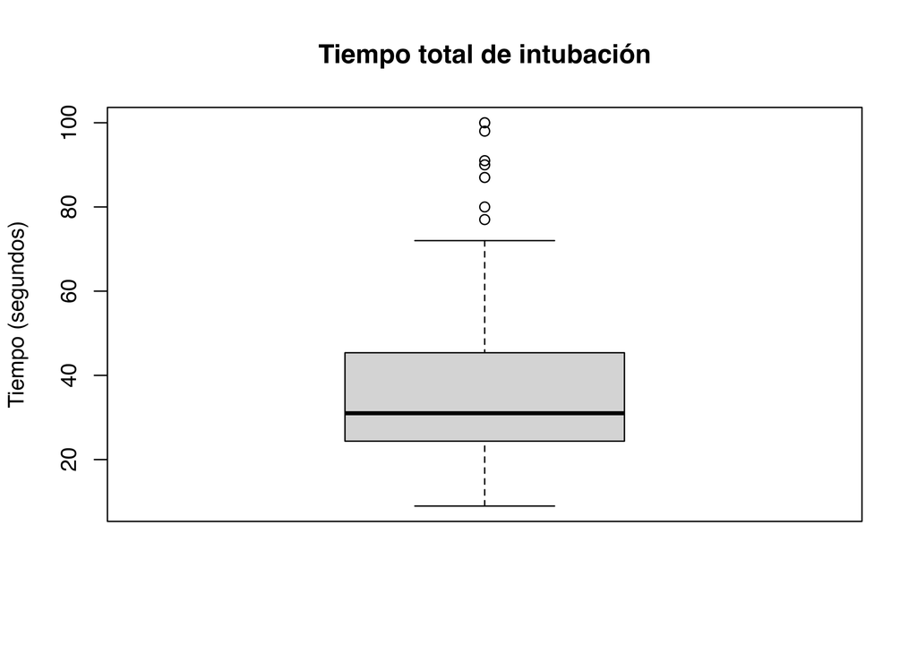

```r
boxplot(laryngoscope$total_intubation_time, main = "Tiempo total de intubación", ylab = "Tiempo (segundos)")
```

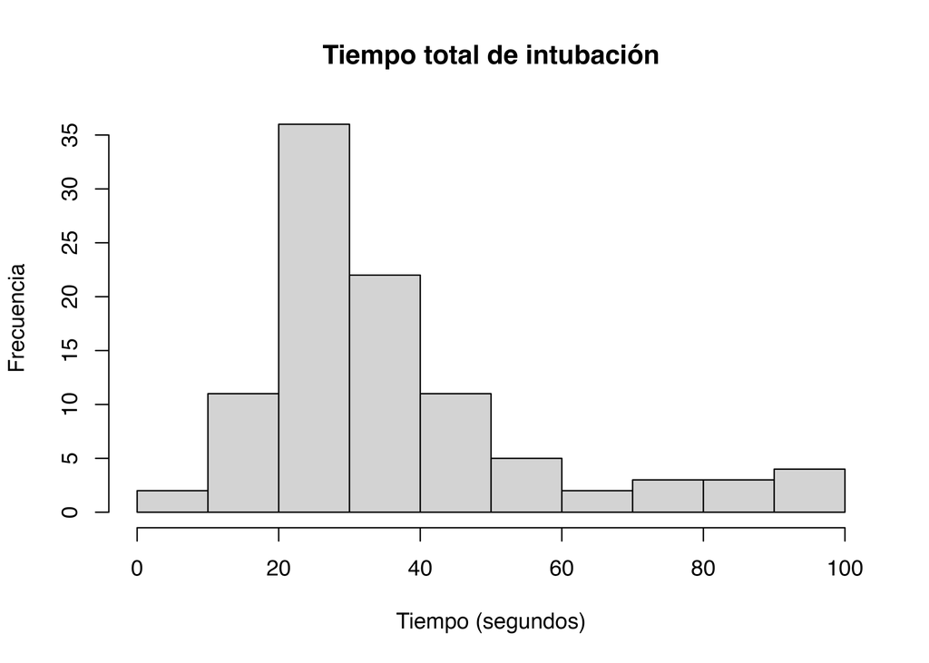

```r
hist(laryngoscope$total_intubation_time, nclass=10, main = "Tiempo total de intubación",xlab = "Tiempo (segundos)", ylab = "Frecuencia")
```

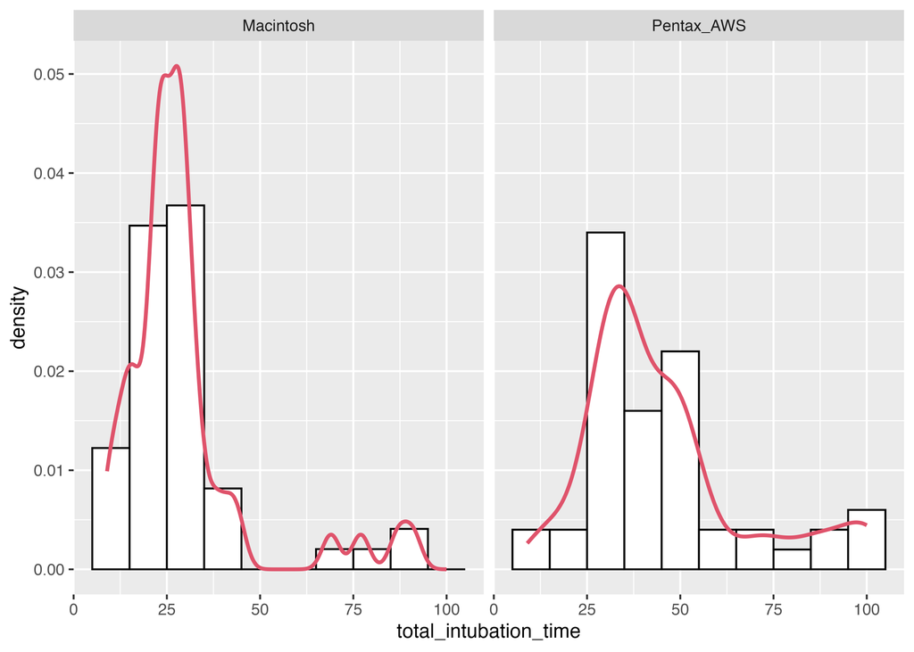

```r
### Tiempo total de intubación por grupos
laryngoscope %>%
  mutate(Randomization = factor(Randomization, labels = c("Macintosh", "Pentax_AWS"))) %>%
  ggplot(aes(x = total_intubation_time )) +
       geom_histogram(aes(y = ..density..), colour = 1, fill = "white",binwidth = 10) +
       geom_density(col=2, lwd=1) +
       facet_wrap(~ Randomization)
```

```r
###### Dificultad de intubación
table(laryngoscope$ease) # En tabla
```

```
#>
#>   0   2   5  10  15  20  25  30  35  40  50  55  60  70  75  80  85  90 100
#>   2   1   4  13   8   5   3   6   2   9   2   1  14   6   2   6   5   5   5
```

```r
summary(laryngoscope$ease) # Estadísticos resumen
```

```
#>    Min. 1st Qu.  Median    Mean 3rd Qu.    Max.
#>    0.00   15.00   40.00   45.22   70.00  100.00
```

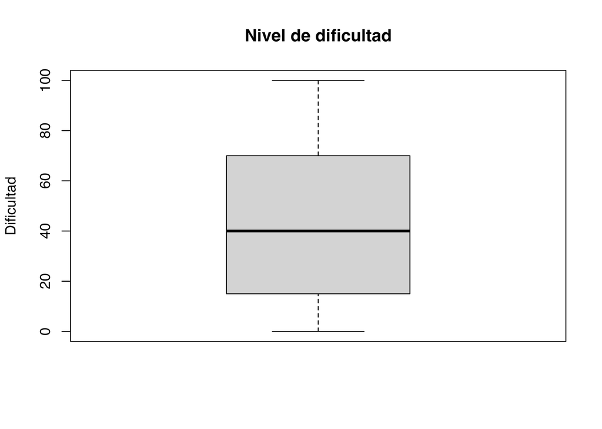

```r
boxplot(laryngoscope$ease, main = "Nivel de dificultad", ylab = "Dificultad")
```

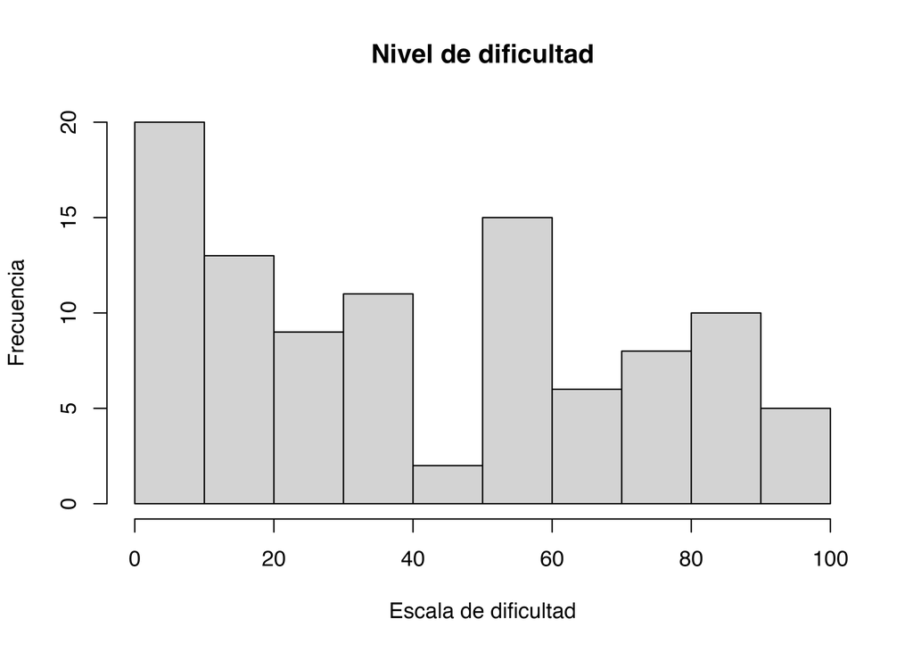

```r
hist(laryngoscope$ease, nclass=10, main = "Nivel de dificultad",xlab = "Escala de dificultad", ylab = "Frecuencia")
```

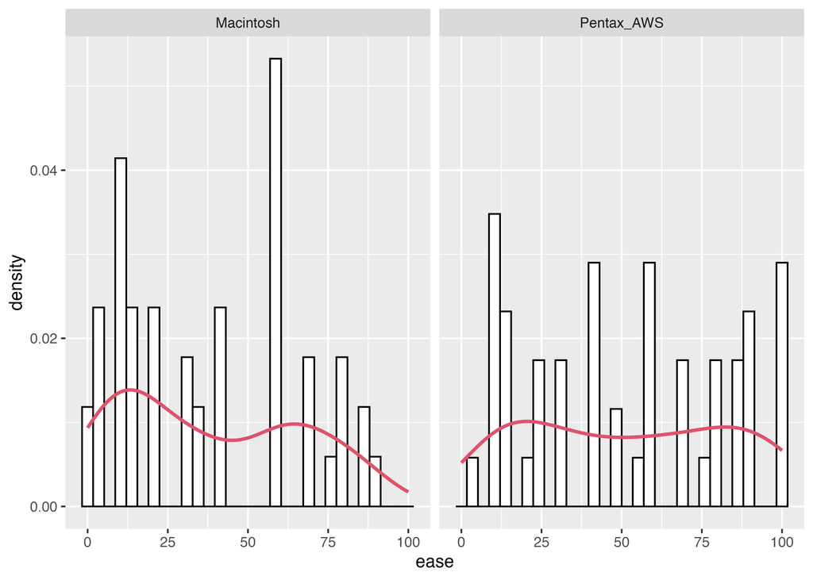

```r
### Dificultad de intubación por grupos
laryngoscope %>%
  mutate(Randomization = factor(Randomization, labels = c("Macintosh", "Pentax_AWS"))) %>%
  ggplot(aes(x = ease)) +
       geom_histogram(aes(y = ..density..), colour = 1, fill = "white") +
       geom_density(col=2, lwd=1) +
       facet_wrap(~ Randomization)
```